# Salinity variation, plant-herbivore interactions and community structure on rocky shores - Ordination Plots and Models

Theraesa Coyle, Rebecca Kordas, Sandra Emry & Chris Harley

15/09/2021

```r
knitr::opts_chunk$set(message = FALSE, warning = FALSE, echo = TRUE)
```

### Survey Data

#### Preparing the dataset

```r
# read in dataset for field transects
transect <- read_csv(here::here("data", "tidy", "field_transect_tidy.csv"))

#creating a unique name for each transect to be used as row names
transect <- transect %>%
  unite(col = "site_rep_month", c("site", "quadrat_no", "month"), sep = "_", remove = FALSE) %>%
  mutate(site = factor(site, levels = c("Eagle Cove", "Hailstorm 2", "Ruckle", "Horseshoe Bay", "Lions Bay 2", "Rope Site 2")),
         month = factor(month, levels = c("May", "June", "July", "September")),
         salinity_regime = factor(salinity_regime, levels = c("L", "H")))

# parse out only the species data, and getting rid of redundant variables
survey_comm_data <- transect %>%
  select(balanus_pt:hermit_crab_no) %>%
  select(-c("barnacles_total_pt", "greens_pyropia_pt", "reds_pt", "reds_fucus_pt", "all_limpets_no", "littorina_total_no", "gastropods_no", "greens_pt"))

survey_env_data <- transect %>%
  select(month, site, salinity_regime) %>%
  mutate(salinity_regime = factor(salinity_regime),
         month = factor(month))
```

#### NMDS on survey data

NMDS attempts to represent the pairwise dissimilarity between samples in a low dimensional space. It is a rank based approach, meaning the original distance data is substituted with ranks. Information about the magnitude of distances is lost, but it rectifies the ‘horseshoe effect’ that occurs with PCoA, due to an assumption of linear relationships among species abundances.

NMDS is an iterative algorithm, beginning with random placement of data objects in ordination space. The algorithm then begins to refine this placement by an iterative process, attempting to find an ordination in which ordinated object distances closely match the order of object dissimilarities in the original distance matrix. The stress value reflects how well the ordination summarizes the observed distances among the samples.

To begin, NMDS requires a distance matrix, or a matrix of dissimilarities. Raw Euclidean distances are not ideal for this purpose: they’re sensitive to total abundances, so may treat sites with a similar number of species as more similar, even though the identities of the species are different. They’re also sensitive to species absences, so may treat sites with the same number of absent species as more similar.

Consequently, ecologists use the Bray-Curtis dissimilarity calculation, which has a number of ideal properties:

It is invariant to changes in units. It is unaffected by additions/removals of species that are not present in two communities, It is unaffected by the addition of a new community, It can recognize differences in total abundances when relative abundances are the same

Finding the number of axes that keep the stress of the ordination low:

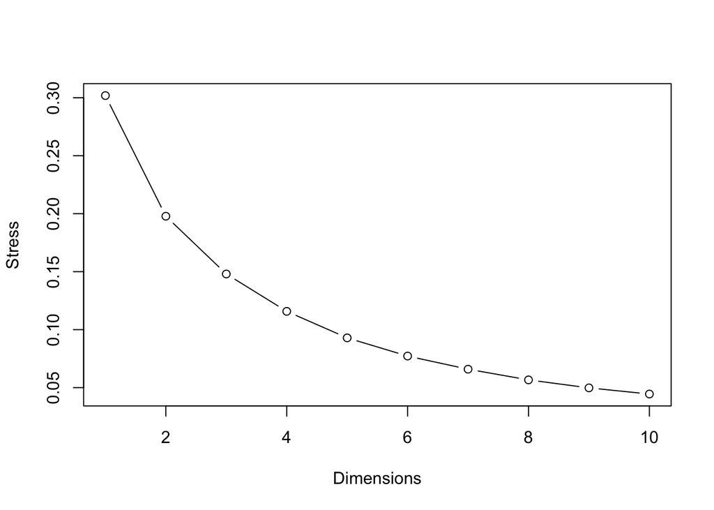

```r
# Fit NMDS solutions for a number of k
k_vec <- 1:10
stress <- numeric(length(k_vec))
survey_dij <- metaMDSdist(survey_comm_data, autotransform = TRUE, trace = FALSE, distance = "bray")
set.seed(25)

for(i in seq_along(k_vec)) {
    sol <- metaMDSiter(survey_dij, k = i,
                       trace = FALSE)
    stress[i] <- sol$stress
}

plot(k_vec, stress, type = "b", ylab = "Stress",
     xlab = "Dimensions")
```

It looks like there isn’t much improvement in the ordination past 3 dimensions so I’m continuing with that for now. I’m going to rerun the NMDS now with 3 dimensions.

Currently, I’m using the double Wisconsin transformation inside the metaMDS wrapper. This standardizes species to equal maxima, then sites to equal totals; this puts equalize emphasis among sample units and among species.

```r
set.seed(31)
nmds_survey <- metaMDS(survey_comm_data, k = 3, trymax = 100, trace = TRUE, autotransform = TRUE, distance = "bray")
```

```
## Square root transformation
## Wisconsin double standardization
## *** Solution reached
```

```r
nmds_survey
```

```
##
## Call:
## metaMDS(comm = survey_comm_data, distance = "bray", k = 3, trymax = 100,      autotransform = TRUE, trace = TRUE)
##
## global Multidimensional Scaling using monoMDS
##
## Data:     wisconsin(sqrt(survey_comm_data))
## Distance: bray
##
## Dimensions: 3
## Stress:     0.1479056
## Stress type 1, weak ties
## Two convergent solutions found after 30 tries
## Scaling: centring, PC rotation, halfchange scaling
## Species: expanded scores based on 'wisconsin(sqrt(survey_comm_data))'
```

**Stress and goodness of fit plots:** Large circles around sites indicate that the model is not fitting those sites very well.

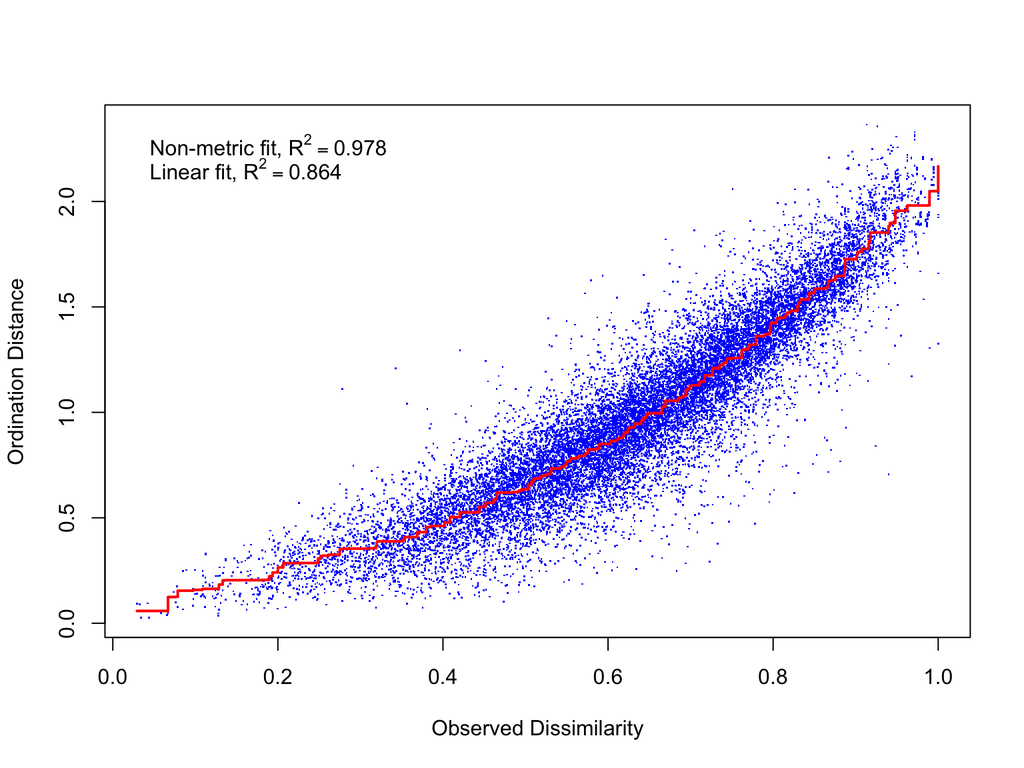

```r
gof <- goodness(nmds_survey)

stressplot(nmds_survey)
```

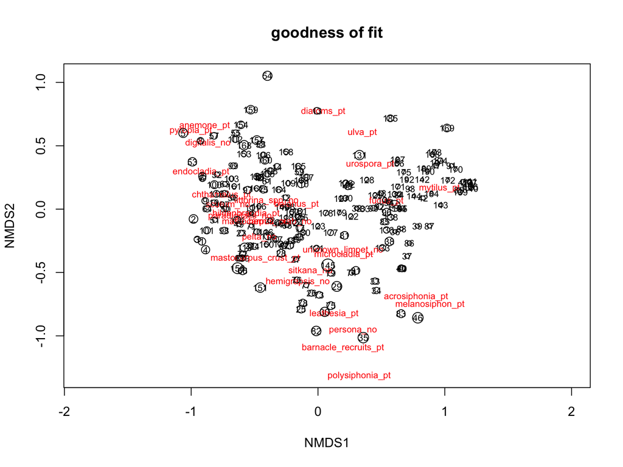

```r
plot(nmds_survey, type="t", main = "goodness of fit")
points(nmds_survey, display="sites", cex=gof*100)
```

#### Plotting the results

Obtain the coordinates for your NMDS1 and NMDS2 axes and put them in a new data frame: I’ve called this new data frame, “data.scores.hell”, or “data.scores.wisc”. Then, add columns with the information that we want to show on the plot - site, month, salinity regime. I’m currently not showing any species information on the plot. Do we want to?

The function ‘envfit’ is fitting a salinity vector onto the ordination with linear regression. Do we want to include this vector? If yes, I need to figure out how to put an arrow head on to it. (Currently not on the plot below)

```r
# salinity <- transect %>%
#   select(salinity_ppt)

# regions <- rep(c(rep("high_salinity", 24), rep("low_salinity", 24)), 4)

# ef <- envfit(nmds_survey, salinity, permu = 999)
# ef_coord_cont <-  as.data.frame(scores(ef, "vectors"))

#extract NMDS scores (x and y coordinates)
data.scores <- as.data.frame(scores(nmds_survey))

#add columns to data frame
data.scores$Site <- transect$site
data.scores$Month <- transect$month
data.scores$Salinity <- transect$salinity_regime
```

Plot with ellipses drawn for salinity regime and month:

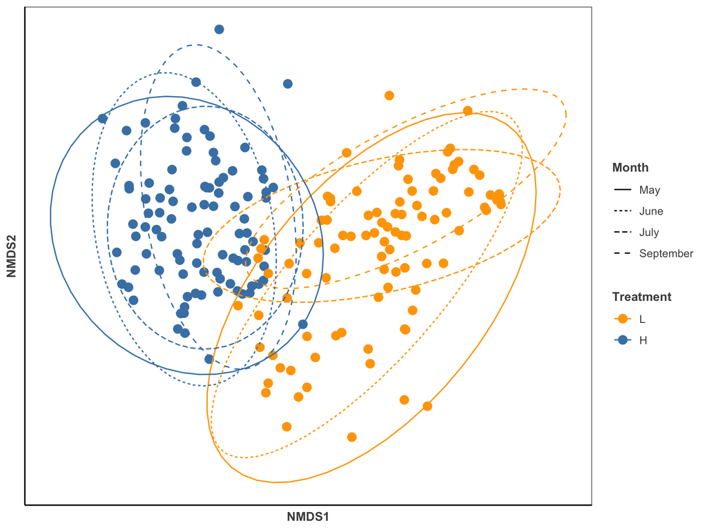

```r
survey_nmds <- ggplot(data = data.scores, aes(x = NMDS1, y = NMDS2)) +
  geom_point(aes(colour = Salinity), size = 3) +
   scale_colour_manual(values = c("orange", "steelblue"))  +
  stat_ellipse(aes(colour = Salinity, linetype = Month)) +
 theme(axis.title = element_text(size = 10, face = "bold", colour = "grey30"),
       panel.background = element_blank(), panel.border = element_rect(fill = NA, colour = "grey30"),
       axis.ticks = element_blank(), axis.text = element_blank(), legend.key = element_blank(),
       legend.title = element_text(size = 10, face = "bold", colour = "grey30"),
       legend.text = element_text(size = 9, colour = "grey30")) +
     labs(colour = "Treatment")

survey_nmds
```

```r
ggsave(filename = "survey_nmds.png", plot = survey_nmds, path = here::here("figures"), width = 16, height = 10, units = "cm")
```

Plot with ellipses drawn for salinity regime and site:

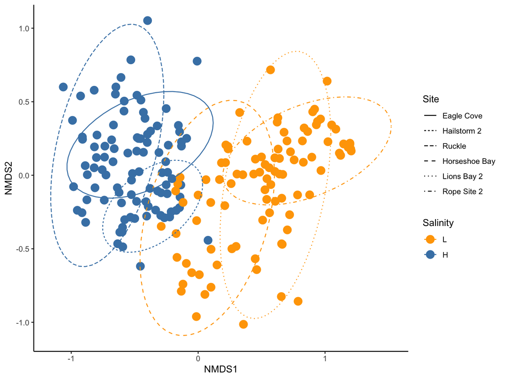

```r
## Plotting with ellipses for site instead and leaving month info out
ggplot(data = data.scores, aes(x = NMDS1, y = NMDS2)) +
  geom_point(aes(colour = Salinity), size = 4) +
   scale_colour_manual(values = c("orange", "steelblue"))  +
  stat_ellipse(aes(colour = Salinity, linetype = Site))
```

### Permanova on survey data

Permutational multivariate analysis of variance (PERMANOVA) is a non-parametric multivariate statistical test. It is used to compare groups of objects and test the null hypothesis that the centroids and dispersion of the groups as defined by measure space are equivalent for all groups. A rejection of the null hypothesis means that either the centroid and/or the spread of the objects is different between the groups. Hence the test is based on the prior calculation of the distance between any two objects included in your experiment.

PERMANOVA assumes no distribution, allows for differences in between-group variation, is insensitive to multicollinearity, allows for multiple variables and is insensitive to many zeros.

**Assumptions:**

Objects in the data set are exchangeable under the null hypothesis Exchangeable objects (sites, samples, observations, etc) are independent Exchangeable objects have similar multivariate disperson (i.e. each group has a similar degree of multivariate scatter)

*Notes* I am restricting the permutations so that it keeps a transect’s 8 quadrats together, because we know these are not independent from one another. I am not incorporating temporal autocorrelation in to the permutation scheme because we are including that as a fixed effect. (But no matter how we permute the data, the two fixed effects and their interaction are always significant)

```r
perm <- how(within = Within(type = "free", mirror = TRUE),
     plots = Plots(strata = transect$site, mirror = TRUE, type = "free"),
     blocks = NULL) # maintaining the dependence of quadrats along a transect

survey_perma <- adonis(survey_comm_data ~ salinity_regime * month, data = transect, permutations = perm, method = "bray") # take site out of adonis call

survey_perma
```

```
##
## Call:
## adonis(formula = survey_comm_data ~ salinity_regime * month,      data = transect, permutations = perm, method = "bray")
##
## Plots: transect$site, plot permutation: free mirrored
## Permutation: free
## Number of permutations: 199
##
## Terms added sequentially (first to last)
##
##                        Df SumsOfSqs MeanSqs F.Model      R2 Pr(>F)
## salinity_regime         1    14.763 14.7628  81.176 0.28613  0.005 **
## month                   3     2.445  0.8149   4.481 0.04738  0.005 **
## salinity_regime:month   3     0.926  0.3086   1.697 0.01794  0.005 **
## Residuals             184    33.462  0.1819         0.64855
## Total                 191    51.595                 1.00000
## ---
## Signif. codes:  0 '***' 0.001 '**' 0.01 '*' 0.05 '.' 0.1 ' ' 1
```

```r
df <- data.frame(treatments = c("salinity region", "month", "salinity region x month", "residuals", "total"), df = survey_perma$aov.tab$Df, SS = survey_perma$aov.tab$SumsOfSqs, MS = survey_perma$aov.tab$MeanSqs, `pseudo F` = survey_perma$aov.tab$F.Model, R2 = survey_perma$aov.tab$R2, `p value` = survey_perma$aov.tab$`Pr(>F)`)

df[ , 3:6] <- round(df[, 3:6], 2)

write_csv(df, "/Users/sandraemry/Documents/coyle_paper/results/perma_survey.csv",
       col_names = TRUE)
```

An assumption of permanova is that each factor has equal multivariate spread. The month to month data does not meet this assumption.

```r
# analogous to Levene's test for homogeneity of variances.

# standardize data with wisconsin method, then calculate a matrix of Bray-Curtis distances
dist <- vegdist(wisconsin(survey_comm_data), method = "bray")
dispersion_salinity <- betadisper(dist, group=transect$salinity_regime)
survey_disp_salnity <- permutest(dispersion_salinity) # equal variance between salinity regimes

survey_disp_salnity_df <- data.frame(Df = survey_disp_salnity$tab$Df,
           SS = survey_disp_salnity$tab$`Sum Sq`,
           MS = survey_disp_salnity$tab$`Mean Sq`,
           `F` = survey_disp_salnity$tab$`F`,
           N.Perm = survey_disp_salnity$tab$N.Perm,
           `Pr(>F)` = survey_disp_salnity$tab$`Pr(>F)`)

survey_disp_salnity_df[is.na(survey_disp_salnity_df)] <- ""

write_csv(survey_disp_salnity_df, here::here("results", "survey_disp_salnity.csv"))

dispersion_month <- betadisper(dist, group=transect$month)
survey_disp_month <- permutest(dispersion_month)# different variances between months
survey_disp_month_df <- data.frame(Df = survey_disp_month$tab$Df,
           SS = survey_disp_month$tab$`Sum Sq`,
           MS = survey_disp_month$tab$`Mean Sq`,
           `F` = survey_disp_month$tab$`F`,
           N.Perm = survey_disp_month$tab$N.Perm,
           `Pr(>F)` = survey_disp_month$tab$`Pr(>F)`)

survey_disp_month_df[is.na(survey_disp_month_df)] <- ""

write_csv(survey_disp_month_df, here::here("results", "survey_disp_month.csv"))

png("survey_betadisper_month.png")
plot(dispersion_month, hull=FALSE, ellipse=TRUE) ## sd ellipse
dev.off()
```

```r
png("survey_betadisper_salinity.png")
plot(dispersion_salinity, hull=FALSE, ellipse=TRUE) ##sd ellipse
dev.off()
```

```r
TukeyHSD(dispersion_month) # May and June have different amounts of variance compared to July
```

```
##   Tukey multiple comparisons of means
##     95% family-wise confidence level
##
## Fit: aov(formula = distances ~ group, data = df)
##
## $group
##                       diff         lwr          upr     p adj
## June-May       -0.02172600 -0.06664654  0.023194547 0.5935287
## July-May       -0.07364002 -0.11856057 -0.028719479 0.0001963
## September-May  -0.04154880 -0.08646934  0.003371746 0.0810157
## July-June      -0.05191403 -0.09683457 -0.006993482 0.0162810
## September-June -0.01982280 -0.06474335  0.025097743 0.6628506
## September-July  0.03209122 -0.01282932  0.077011769 0.2525990
```

### Field experimental data

#### Prepping the dataset:

Now I am going to ordinate the experimental field data in the same way as above. We are only considering the month of July. I’m going to take out the cumulative columns: greens, reds, greens_pyropia, reds_fucus becasue they include species already accounted for in other columns.

```r
exp <- read_csv(here::here("data", "tidy", "field_exclusion_tidy.csv"))

exp <- exp %>%
  unite(col = "site_rep_treatment", c("site", "replicate", "treatment"), sep = "_", remove = FALSE) %>%
  dplyr::mutate(treatment = factor(treatment),
         site = factor(site, levels = c("Eagle Cove", "Hailstorm 2", "Ruckle", "Horseshoe Bay", "Lions Bay 2", "Rope Site 2")))

exp_comm_data <- exp %>%
  dplyr::select(-c("greens_pyropia", "reds", "reds_fucus", "greens")) %>%
  dplyr::select(balanus_no:fucus_pt)
```

#### NMDS on field experiment

Finding the number of axes that limit the stress on the ordination for the experimental data.

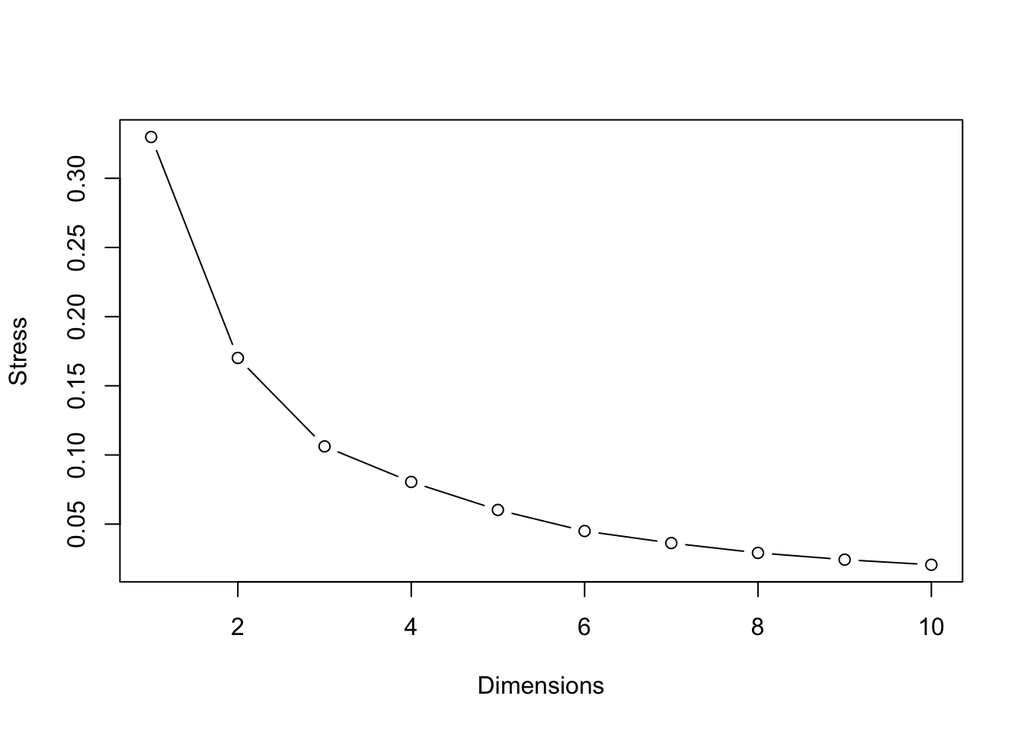

Performing a Wisconsin data transformation within the NMDS:

```
## Square root transformation
## Wisconsin double standardization
## *** Solution reached
```

```
##
## Call:
## metaMDS(comm = exp_comm_data, distance = "bray", k = 3, trymax = 100,      autotransform = TRUE, trace = TRUE)
##
## global Multidimensional Scaling using monoMDS
##
## Data:     wisconsin(sqrt(exp_comm_data))
## Distance: bray
##
## Dimensions: 3
## Stress:     0.1061944
## Stress type 1, weak ties
## Two convergent solutions found after 20 tries
## Scaling: centring, PC rotation, halfchange scaling
## Species: expanded scores based on 'wisconsin(sqrt(exp_comm_data))'
```

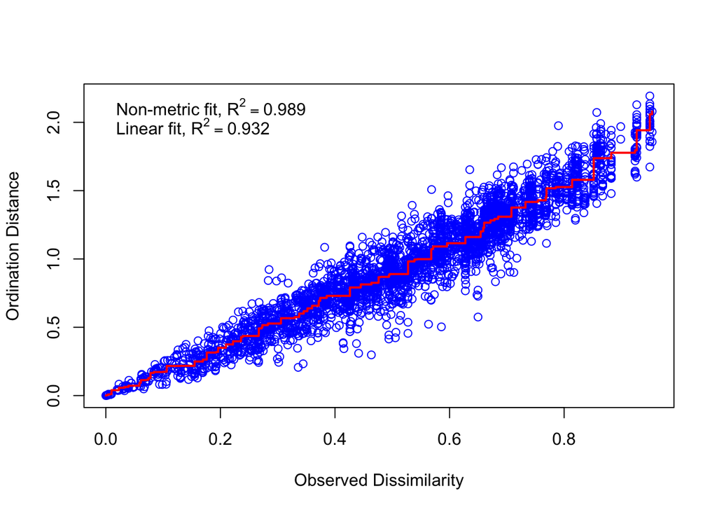

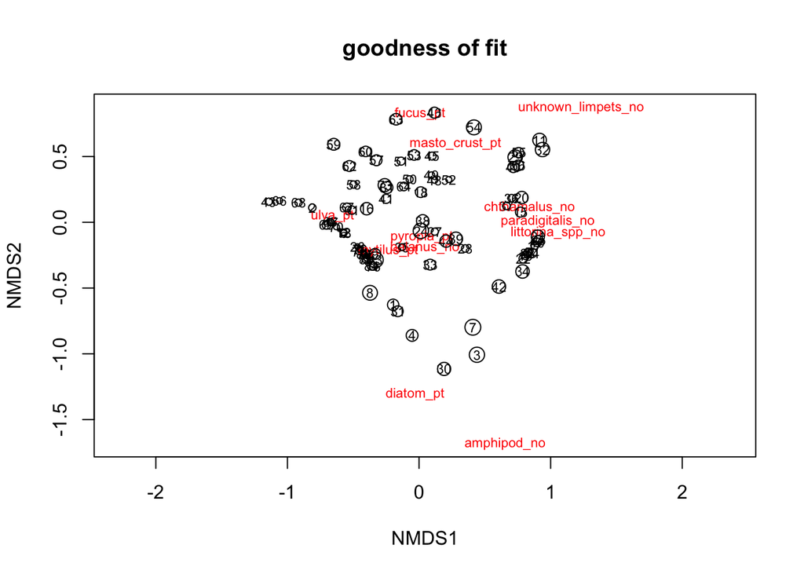

Plotting the results:

```
##         NMDS1       NMDS2       NMDS3   Site Salinity Treatment
## 1 -0.19686026 -0.62728190  0.21802830 Ruckle     High         E
## 2 -0.81091914  0.11108155 -0.04956453 Ruckle     High         C
## 3  0.43982598 -1.00718762 -0.22404180 Ruckle     High         C
## 4 -0.05272778 -0.86004854  0.24813850 Ruckle     High         E
## 5  0.82952405 -0.22711018 -0.03177756 Ruckle     High         C
## 6 -0.57095225 -0.07945186 -0.04668827 Ruckle     High         E
```

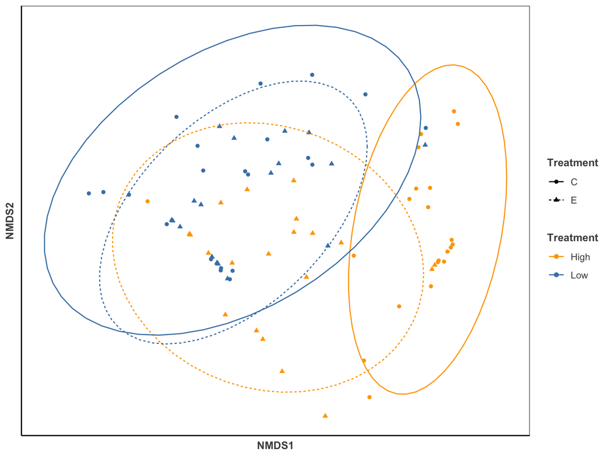

#### Permanova on field experiment:

```
##
## Call:
## adonis(formula = exp_comm_data ~ region * treatment, data = exp_env_data,      permutations = perm_site, method = "bray")
##
## Plots: exp_env_data$site, plot permutation: free
## Permutation: free
## Number of permutations: 199
##
## Terms added sequentially (first to last)
##
##                  Df SumsOfSqs MeanSqs F.Model      R2 Pr(>F)
## region            1    0.9666 0.96659  8.2042 0.08809  0.375
## treatment         1    0.4013 0.40132  3.4063 0.03657  0.005 **
## region:treatment  1    0.1796 0.17955  1.5240 0.01636  0.025 *
## Residuals        80    9.4252 0.11782         0.85897
## Total            83   10.9727                 1.00000
## ---
## Signif. codes:  0 '***' 0.001 '**' 0.01 '*' 0.05 '.' 0.1 ' ' 1
```

Are there different levels of dispersion in region and treatment?

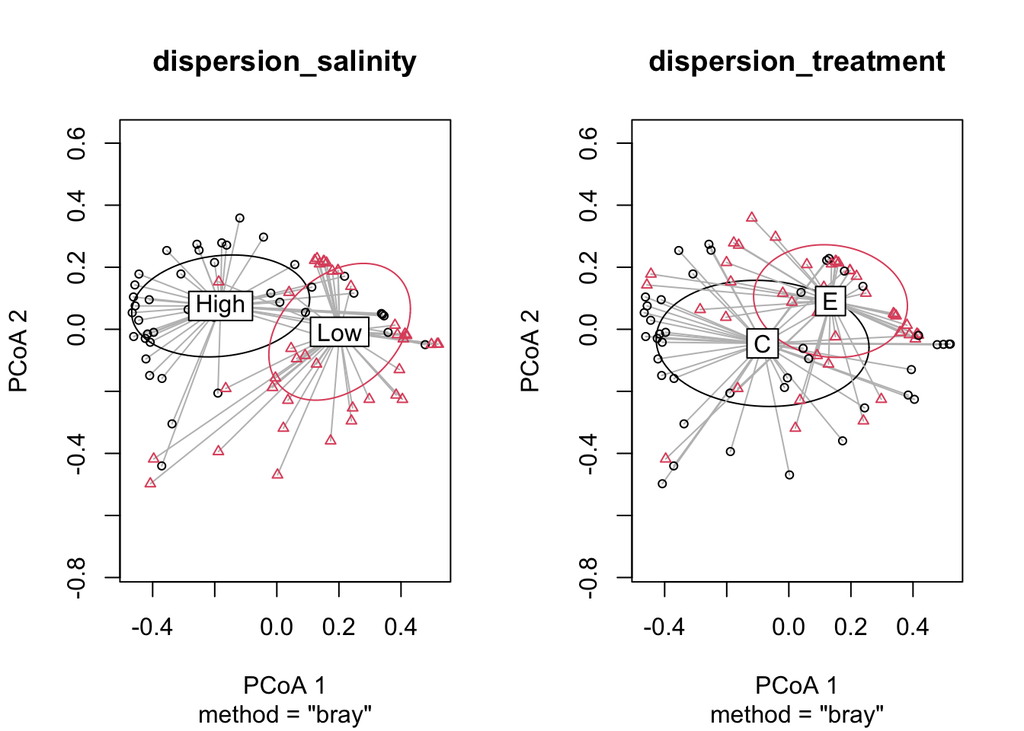

```r
# analogous to Levene's test for homogeneity of variances.

# standardize data with wisconsin method, then calculate a matrix of Bray-Curtis distances
dist <- vegdist(wisconsin(exp_comm_data), method = "bray")
dispersion_salinity <- betadisper(dist, group = exp_env_data$region)
exp_disp_salinity <- permutest(dispersion_salinity) # greater dispersion in high salinity region

exp_disp_salinity_df <- data.frame(Df = exp_disp_salinity$tab$Df,
           SS = exp_disp_salinity$tab$`Sum Sq`,
           MS = exp_disp_salinity$tab$`Mean Sq`,
           `F` = exp_disp_salinity$tab$`F`,
           N.Perm = exp_disp_salinity$tab$N.Perm,
           `Pr(>F)` = exp_disp_salinity$tab$`Pr(>F)`)

exp_disp_salinity_df[is.na(exp_disp_salinity_df)] <- ""

write_csv(exp_disp_salinity_df, here::here("results", "exp_disp_treatment.csv"))

dispersion_treatment <- betadisper(dist, group=exp_env_data$treatment)
exp_disp_treatment <- permutest(dispersion_treatment) # greater dispersion in the control

exp_disp_treatment_df <- data.frame(Df = exp_disp_treatment$tab$Df,
           SS = exp_disp_treatment$tab$`Sum Sq`,
           MS = exp_disp_treatment$tab$`Mean Sq`,
           `F` = exp_disp_treatment$tab$`F`,
           N.Perm = exp_disp_treatment$tab$N.Perm,
           `Pr(>F)` = exp_disp_treatment$tab$`Pr(>F)`)

exp_disp_treatment_df[is.na(exp_disp_treatment_df)] <- ""

write_csv(exp_disp_treatment_df, here::here("results", "exp_disp_salnity.csv"))

par(mfrow = c(1,2))
plot(dispersion_salinity, hull = FALSE, ellipse = TRUE) # sd ellipse
plot(dispersion_treatment, hull = FALSE, ellipse = TRUE) # sd ellipse
```

```r
png("exp_betadisper_treatment.png")
plot(dispersion_treatment, hull=FALSE, ellipse=TRUE) ## sd ellipse
dev.off()
```

```r
png("exp_betadisper_salinity.png")
plot(dispersion_salinity, hull=FALSE, ellipse=TRUE) ##sd ellipse
dev.off()
```

NMDS on experiment data when simplified to presence/absence

```r
exp_comm_data_PA <- exp_comm_data
for (i in 1:nrow(exp_comm_data)){
  for (j in 1:ncol(exp_comm_data)){
    if (exp_comm_data[i,j] > 0){
      exp_comm_data_PA[i,j] <-1
    }
  }
}

set.seed(1126)
nmds_exp_PA <- metaMDS(exp_comm_data_PA, k = 2, trymax = 100, trace = TRUE, autotransform = FALSE, distance = "jaccard")
```

```
## *** Solution reached
```

```r
nmds_exp_PA
```

```
##
## Call:
## metaMDS(comm = exp_comm_data_PA, distance = "jaccard", k = 2,      trymax = 100, autotransform = FALSE, trace = TRUE)
##
## global Multidimensional Scaling using monoMDS
##
## Data:     exp_comm_data_PA
## Distance: jaccard
##
## Dimensions: 2
## Stress:     0.1097298
## Stress type 1, weak ties
## Two convergent solutions found after 29 tries
## Scaling: centring, PC rotation, halfchange scaling
## Species: expanded scores based on 'exp_comm_data_PA'
```

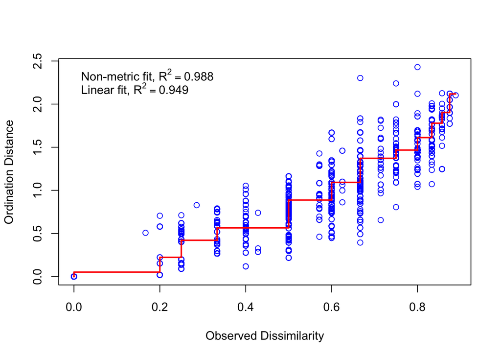

```r
gof_exp <- goodness(nmds_exp_PA)

stressplot(nmds_exp_PA)
```

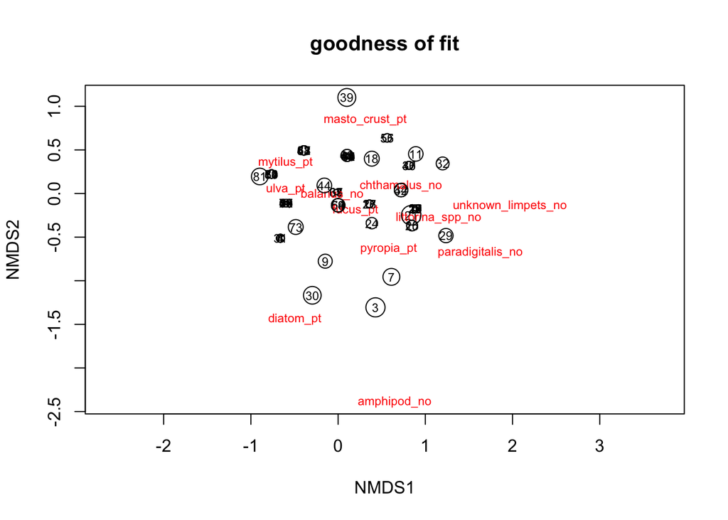

```r
plot(nmds_exp_PA, type = "t", main = "goodness of fit")
points(nmds_exp_PA, display ="sites", cex = gof_exp*100)
```

```r
# ef <- envfit(nmds_exp_PA, env_factors, permu = 999)

#extract NMDS scores (x and y coordinates)
data.scores = as.data.frame(scores(nmds_exp_PA))

#add columns to data frame
data.scores$Site <-  exp$site
data.scores$Salinity <-  exp$region
data.scores$Treatment <-  exp$treatment

head(data.scores)
```

```
##        NMDS1      NMDS2   Site Salinity Treatment
## 1 -0.6611458 -0.5132567 Ruckle     High         E
## 2 -0.5951161 -0.1068300 Ruckle     High         C
## 3  0.4281906 -1.3053007 Ruckle     High         C
## 4 -0.6611458 -0.5132567 Ruckle     High         E
## 5  0.8850780 -0.1721742 Ruckle     High         C
## 6 -0.5951161 -0.1068300 Ruckle     High         E
```

```r
exp_PA_nmds <- ggplot(data = data.scores, aes(x = NMDS1, y = NMDS2)) +
  geom_point(aes(shape = Treatment, colour = Salinity), alpha = 0.5) +
   scale_colour_manual(values = c("orange", "steelblue"))  +
  stat_ellipse(aes(color = Salinity, linetype = Treatment)) +
     theme(axis.title = element_text(size = 10, face = "bold", colour = "grey30"),
       panel.background = element_blank(), panel.border = element_rect(fill = NA, colour = "grey30"),
       axis.ticks = element_blank(), axis.text = element_blank(), legend.key = element_blank(),
       legend.title = element_text(size = 10, face = "bold", colour = "grey30"),
       legend.text = element_text(size = 9, colour = "grey30")) +
     labs(colour = "Treatment")

ggsave(filename = "exp_PA_nmds.png", plot = exp_PA_nmds, path = here::here("figures"), width = 16, height = 10, units = "cm")
```

Collapsing to presence/absence. Region, treatment and interaction are significant

```r
# when performed on presence absence data then the interaction is significant
perm_site <- how(within = Within(type = "free"),
    plots = Plots(strata = exp_env_data$site, type = "free"),
    blocks = NULL)

exp_perma_PA <- adonis(exp_comm_data ~ region * treatment, data = exp_env_data, permutations = perm_site, method = "jaccard", binary = TRUE)

exp_perma_PA
```

```
##
## Call:
## adonis(formula = exp_comm_data ~ region * treatment, data = exp_env_data,      permutations = perm_site, method = "jaccard", binary = TRUE)
##
## Plots: exp_env_data$site, plot permutation: free
## Permutation: free
## Number of permutations: 199
##
## Terms added sequentially (first to last)
##
##                  Df SumsOfSqs MeanSqs F.Model      R2 Pr(>F)
## region            1    2.2830 2.28302 19.7998 0.16902  0.005 **
## treatment         1    1.0339 1.03391  8.9667 0.07654  0.005 **
## region:treatment  1    0.9662 0.96618  8.3794 0.07153  0.005 **
## Residuals        80    9.2244 0.11531         0.68291
## Total            83   13.5075                 1.00000
## ---
## Signif. codes:  0 '***' 0.001 '**' 0.01 '*' 0.05 '.' 0.1 ' ' 1
```

```r
df <- data.frame(treatments = c("salinity region", "treatment", "salinity region x treatment", "residuals", "total"), df = exp_perma_PA$aov.tab$Df, SS = exp_perma_PA$aov.tab$SumsOfSqs, MS = exp_perma_PA$aov.tab$MeanSqs, `pseudo F` = exp_perma_PA$aov.tab$F.Model, R2 = exp_perma_PA$aov.tab$R2, `p value` = exp_perma_PA$aov.tab$`Pr(>F)`)

df[ , 3:6] <- round(df[, 3:6], 2)

write_csv(df, "/Users/sandraemry/Documents/coyle_paper/results/perma_exp_PA.csv",
       col_names = TRUE)
```

###### Separating to algae vs animals

I can’t separate this way because the design is again unbalanced! There are plots with no algae in them

###### Separating to sessile vs mobile

Also can’t do this because many plots don’t have any mobile inverts in them